# D3 math

# Introduction

This post is inspired by a discussion that sparkled in one of D3 Switch groups, and revolves around the probability of having a full set of primal items. I try to skip all the math lingo, and present it in a way any player can understand. So statisticians of the wolrd, sorry for not using correct or precise terminology here ;)

As you may, or may not know, D3 on any console is different from PC versions, because savegames are not stored online, but on users device, and they are (relatively) easy accessible. I would divide the cheating into following categories

## Casuals

They do not edit saves per se, but just restore the save all over to get nice things (like, you open a cache, and if you do not like what was inside you reload and open again). This by itself is very limited.

## Noob wannabees

GR150 run 20 minutes after season start. Edit the save, give yourself items with ridiculous stats (rings with 3 sockets, 10000000 pickup radius, gorillion damage, bazillion XP modifiers etc). Or just, give yourself 20000 paragon directly (since console leaderboards do not show paragon).

## Intermediate

These edit your party member instead. You get carried on the 150 and still get insane boost via party modifiers, but your main remains clear. Do it in 3-man party, which noone ever looks up and you are set for success. You can still show a very nice solo, 2-man or 4-man clear, without any direct links to what you did (since people have to look up your party memebers, which involves manual scrolling on a slow slow leaderboard with no pagedown/pageup XD )

# Pros

Play normal game, but give yourself reasonable boosts - like, once you get a certain item normally, give it a bit of the boost in the form of perfect stats.

# How to detect it?

As you can see, the first 3 are kinda obvious - you will see a GR150 clear on some of the leaderboards, and someone in the party will be hacked to the maxxx. Pros hovever, are really hard to detect, because they don’t do anything, that wouldn’t be achievable in a normal way, or do they?

# Reforge in Diablo 3

# Reforging 1 item

We start with assumption, that there is a 1/400 chance to get a Primal with each reforge.

If we want to know, what is the probability of geting at least one Primal after reforging N times, we inverse the problem - we simplify the calculation by looking at the probability of failing after N tries and substract it from 1. Basically, a probability of failing is 1-1/400 or 399/400, if we repeat this process N times, the probability of failing will be (1-1/400)^N and probability of success (getting at least 1 primal) is therefore 1 - (1-1/400)^N

(just a note, we don’t solve (1/400)^N , because that will tell us the chance of having exactly one primal after N tries, but there is also a chance to get 1, 2…. N of them, that’s why inversing the problem is useful)

Now lets visualize our chances of getting this shiny primal after a few trials

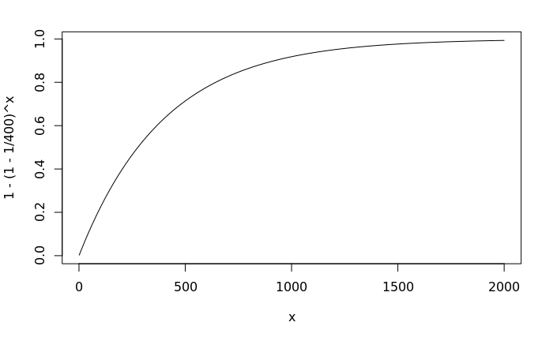

Even after 2000 trials, we cannot be 100% sure that we will get a primal. After 400 trials, our chance of getting at least one is roughly

```r
1-(1-1/400)^400
```

```
[1] 0.6325809
```

or, 63.25% (A lot of players assume, that if an event has a 1/400 chance of occuring, it must occur if they do it 400 times, you can see this is not correct, and they are actually way off)

# Reforging 13 items

Diablo allows us to use 13 items at once, but you rarely see in-season characters have full primal sets. That is, because it is very time consuming to get to that point.

Knowing, what a chance to get one primal in one slot is, we can push it a bit, and look at what would our chance to have a full primal set be, if we reforged every item exactly N times (basically, reforge 13 items, each exactly once, twice, and so on)

For this, we just multiply single probability with its self 13 times, or ( 1-(1-1/400)^x )^13

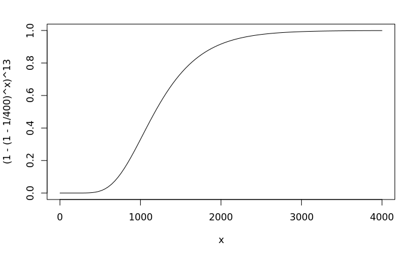

Again, we can never be 100% sure to achieve our result, but in order to get at least somewhere, we need hundreds of reforges just to get to double-digit probability.

If we decide to reforge every item 1000 times (this means, 13000 reforges in total), we would have

```r
(1-(1-1/400)^1000)^13
```

```
[1] 0.3296171
```

roughly 32.96% chance to get full primal set.

If we did this 1926 times

```r
(1-(1-1/400)^1926)^13
```

```
[1] 0.9001582
```

we would get to 90% probability of having a full primal set. 90% is good enough right?

(1926 reforges) * (13 items) * (5 materials) / (cache yield, 22 on t16) gives us easy

```r
1926 * 13 * 5 / 22
```

```
[1] 5690.455
```

5691 bounty runs :D At 5 minutes a run, not counting any downtimes for actually opening the boxes, you would need

```r
5691 * 5 /60
```

```
[1] 474.25
```

```r
5691 * 5 /60/24
```

```
[1] 19.76042
```

474 hours or almost 20 days of uninterrupted game time just on your bounty runs.

That is still doable right? And, if we content with 33% chance of getting there (meaning, 1 out of every 3 players that do this insanity) that 1000 reforges mentioned a bit above get us, it should be possible to see this here and there right?

Yes, but your primals will not perfect

# Getting perfect primals

For the sake of simplicity, I will assume that you look at trifecta in every item on top of guaranteed int/dex/str roll, and we do not care about secondary stats. With a pool of ‘only’ 5 possibilities in each of these slots. This is actually WAY easier than real d3 situation, but should be decent enough to illustrate (items, esp offhands have way bigger pool of mainstats to chose from, on the bright side - some will be guaranteed).

Probability of having perfect trifecta item in this case is -

```r
(1/5)*(1/4)*(1/3)
```

```
[1] 0.01666667
```

or, roughly 1.7% … So, only 17 out of 1000 primals you get, will have perfect rolls on their mainstats, rip.

# Putting it together

To graph this out, we just use this finding and adjust our success rate - we get a primal with 1/400 chance, but to get a perfect one, it is (1/400)* ( (1/5)*(1/4)*(1/3) ) and we plot this just as the probability for any primal

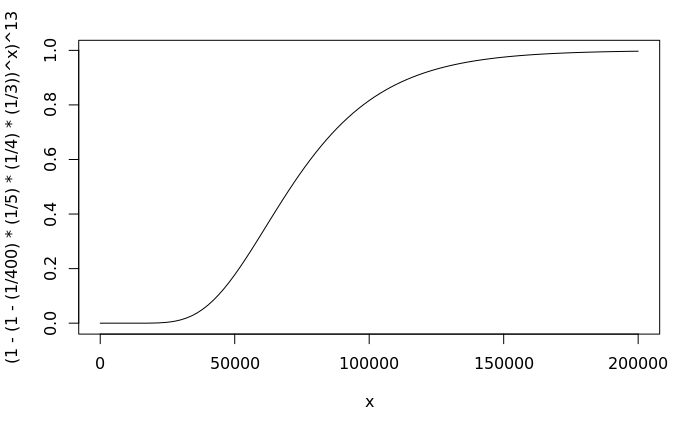

Badum…tsss. The 33% threshold is crossed at 60098 reforges on every single item. (and if you say, this is exaggerated and you only need 2 stats and do not want trifectas - it would be 20032 reforges)

These reforges represent

```r
60098 * 13 * 5 / 22
```

```
[1] 177562.3
```

```r
20032 * 13 * 5 / 22
```

```
[1] 59185.45
```

Bounty runs, or

```r
177562.3 * 5 /60/24
```

```
[1] 616.5358
```

```r
59185.45 * 5 /60/24
```

```
[1] 205.505
```

616 or 205 DAYS of pure bounty farming with no downtime to open the boxes. Keep in mind that average season in D3 lasts maybe 90-120 days. So, next time you see someone ‘maybe legit’, running around with a set of perfectly rolled primals by the end of the season, ask yourself, if he is one of the three people that spent entire season bounty farming, or if they cheated their way in.